# BIOS 611 HW4 Relational data (Chapter 13) and Strings (Chapter 14-15)

Ty Darnell

10/01/2018

(Due date: September 28 at 6 pm)

This set of exercise is mostly taken from R for Data Science by Garrett Grolemund and Hadley Wickham.

# Exercise 1

1. Imagine you wanted to draw on a map the route each plane flies from its origin to its destination. What variables would you need? What tables would you need to combine?

   Answer:

`origin` and `dest` from the `flights` table. longitude and latitude from `airports`. You would need to join `flights` and `airports`

2. We know that some days of the year are “special”, and fewer people than usual fly on them. How might you represent that data as a data frame? What would be the primary keys of that table? How would it connect to the existing tables?

   Answer: add a table of special dates. The primary key is `date`. The values to match are `year` `month` `day`.

# Exercise 2

1. Add a surrogate key to `flights`.

   Answer:

   ```r
   flights%>% mutate(flight_id=row_number())%>%select(flight_id,everything())
   ```

   ```
   ## # A tibble: 336,776 x 20
   ##    flight_id  year month   day dep_time sched_dep_time dep_delay arr_time
   ##        <int> <int> <int> <int>    <int>          <int>     <dbl>    <int>
   ##  1         1  2013     1     1      517            515         2      830
   ##  2         2  2013     1     1      533            529         4      850
   ##  3         3  2013     1     1      542            540         2      923
   ##  4         4  2013     1     1      544            545        -1     1004
   ##  5         5  2013     1     1      554            600        -6      812
   ##  6         6  2013     1     1      554            558        -4      740
   ##  7         7  2013     1     1      555            600        -5      913
   ##  8         8  2013     1     1      557            600        -3      709
   ##  9         9  2013     1     1      557            600        -3      838
   ## 10        10  2013     1     1      558            600        -2      753
   ## # ... with 336,766 more rows, and 12 more variables: sched_arr_time <int>,
   ## #   arr_delay <dbl>, carrier <chr>, flight <int>, tailnum <chr>,
   ## #   origin <chr>, dest <chr>, air_time <dbl>, distance <dbl>, hour <dbl>,
   ## #   minute <dbl>, time_hour <dttm>
   ```

2. Identify the keys in the following datasets

   Answer:
   1. `Lahman::Batting`, Answer: playerID, yearID, stint

   ```r
   Lahman::Batting%>%count(playerID,yearID ,stint)%>%filter(n>1)
   ```

   ```
   ## # A tibble: 0 x 4
   ## # ... with 4 variables: playerID <chr>, yearID <int>, stint <int>, n <int>
   ```

   2. `babynames::babynames` Answer: year, sex, name

   ```r
   babynames::babynames%>%group_by(year,sex,name)%>%filter(n()>1)%>%nrow()
   ```

   ```
   ## [1] 0
   ```

   3. `nasaweather::atmos` Answer: lat, long, year, month

   ```r
   nasaweather::atmos %>%
     group_by(lat, long, year, month) %>%
     filter(n() > 1) %>%
     nrow()
   ```

   ```
   ## [1] 0
   ```

3. Draw a diagram illustrating the connections between the `Batting`, `Master`, and `Salaries` tables in the Lahman package.  
   (A diagram does not have to be a perfect picture. It can be tables with some explanation, or it can be a scanned image of your sketch.)

   Answer: Master - primary keys: playerid Batting - primary keys: yearID, stint foreign keys: playerID=Master$playerId Salaries - primary keys: yearID, teamID, playerID foreign keys: playerId=Master$playerID

# Exercise 3

1. Compute the average arrival delay by destination, then join on the `airports` data frame so you can show the spatial distribution of delays. Here’s an easy way to draw a map of the United States:

   ```r
   airports %>%
     semi_join(flights, c("faa" = "dest")) %>%
     ggplot(aes(lon, lat)) +
       borders("state") +
       geom_point() +
       coord_quickmap()
   ```

   (Don’t worry if you don’t understand what `semi_join()` does — you’ll learn about it next.)

   You might want to use the `colour` of the points to display the average delay for each airport.

   Answer:

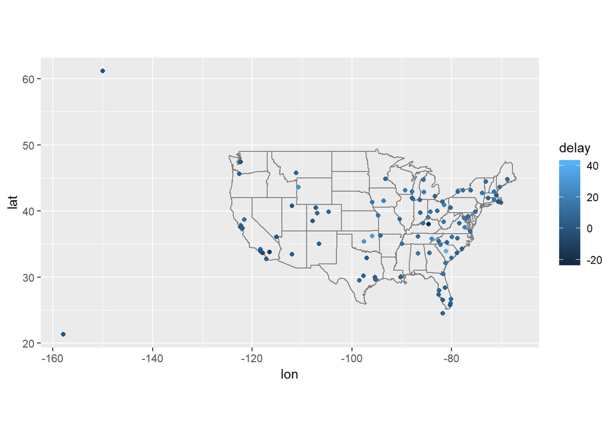

   ```r
    mean_dest_delay <- flights%>%group_by(dest)%>%summarise(delay=mean(arr_delay,na.rm=T))%>%inner_join(airports,by=c(dest="faa"))

   mean_dest_delay%>%
   ggplot(aes(lon, lat,color=delay)) +
       borders("state") +
       geom_point() +
       coord_quickmap()
   ```

2. Add the location of the origin *and* destination (i.e. the `lat` and `lon`) to `flights`.

   Answer:

   ```r
     locations <- airports %>%
     select(faa, lat, lon)

    flights%>%
   select(year:day,hour,origin,dest)%>%left_join(locations,by=c("origin"="faa"))%>%left_join(locations,by=c("dest"="faa"))
   ```

   ```
   ## # A tibble: 336,776 x 10
   ##     year month   day  hour origin dest  lat.x lon.x lat.y lon.y
   ##    <int> <int> <int> <dbl> <chr>  <chr> <dbl> <dbl> <dbl> <dbl>
   ##  1  2013     1     1     5 EWR    IAH    40.7 -74.2  30.0 -95.3
   ##  2  2013     1     1     5 LGA    IAH    40.8 -73.9  30.0 -95.3
   ##  3  2013     1     1     5 JFK    MIA    40.6 -73.8  25.8 -80.3
   ##  4  2013     1     1     5 JFK    BQN    40.6 -73.8  NA    NA
   ##  5  2013     1     1     6 LGA    ATL    40.8 -73.9  33.6 -84.4
   ##  6  2013     1     1     5 EWR    ORD    40.7 -74.2  42.0 -87.9
   ##  7  2013     1     1     6 EWR    FLL    40.7 -74.2  26.1 -80.2
   ##  8  2013     1     1     6 LGA    IAD    40.8 -73.9  38.9 -77.5
   ##  9  2013     1     1     6 JFK    MCO    40.6 -73.8  28.4 -81.3
   ## 10  2013     1     1     6 LGA    ORD    40.8 -73.9  42.0 -87.9
   ## # ... with 336,766 more rows
   ```

3. Is there a relationship between the age of a plane and its delays?

   Answer: There is not a strong relationship between age and delays.

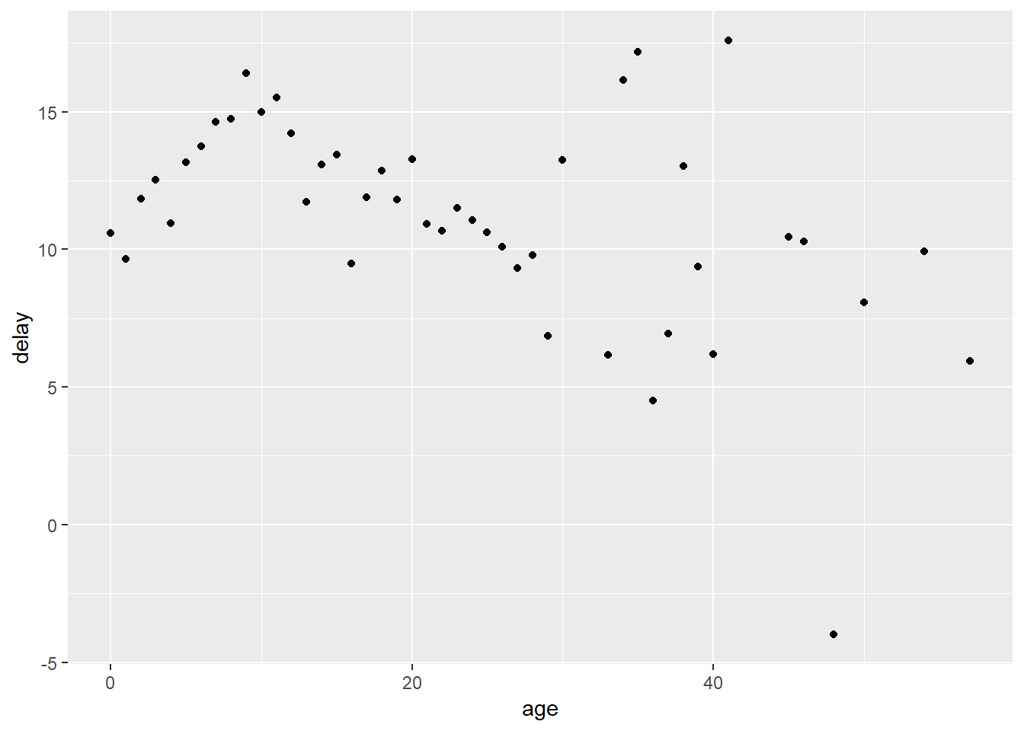

   ```r
   ages <- planes%>%mutate(age=2013-year)%>%select(tailnum,age)

   flights %>%
     inner_join(ages, by = "tailnum") %>%
     group_by(age) %>%
     filter(!is.na(dep_delay)) %>%
     summarise(delay = mean(dep_delay)) %>%
     ggplot(aes(x = age, y = delay)) +
     geom_point()
   ```

4. What happened on June 13 2013? Display the spatial pattern of delays, and then use Google to cross-reference with the weather.

   Answer: There were strong storms, called derechos that hit the southeast, and midwest primarily.

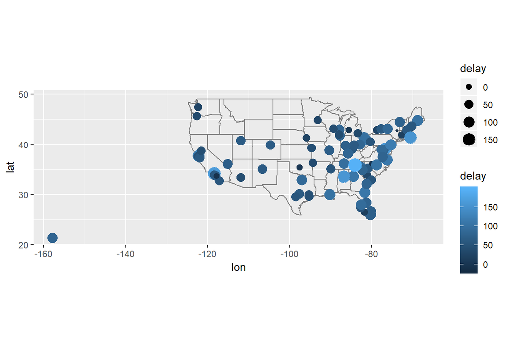

   ```r
   flights%>% filter(year==2013,month==6,day==13)%>%
    group_by(dest)%>%summarise(delay=mean(arr_delay,na.rm=T))%>%inner_join(airports,by=c("dest"="faa"))%>% ggplot(aes(lon, lat,size=delay,color=delay)) +
   borders("state") +
      geom_point() +
    coord_quickmap()
   ```

# Exercise 4

1. Filter flights to only show flights with planes that have flown at least 100 flights.

   Answer:

   ```r
   flights100 = flights %>%group_by(tailnum)%>%count()%>%filter(n>=100)

   flights%>%semi_join(flights100,by="tailnum")
   ```

   ```
   ## # A tibble: 230,902 x 19
   ##     year month   day dep_time sched_dep_time dep_delay arr_time
   ##    <int> <int> <int>    <int>          <int>     <dbl>    <int>
   ##  1  2013     1     1      517            515         2      830
   ##  2  2013     1     1      533            529         4      850
   ##  3  2013     1     1      544            545        -1     1004
   ##  4  2013     1     1      554            558        -4      740
   ##  5  2013     1     1      555            600        -5      913
   ##  6  2013     1     1      557            600        -3      709
   ##  7  2013     1     1      557            600        -3      838
   ##  8  2013     1     1      558            600        -2      849
   ##  9  2013     1     1      558            600        -2      853
   ## 10  2013     1     1      558            600        -2      923
   ## # ... with 230,892 more rows, and 12 more variables: sched_arr_time <int>,
   ## #   arr_delay <dbl>, carrier <chr>, flight <int>, tailnum <chr>,
   ## #   origin <chr>, dest <chr>, air_time <dbl>, distance <dbl>, hour <dbl>,
   ## #   minute <dbl>, time_hour <dttm>
   ```

2. Combine `fueleconomy::vehicles` and `fueleconomy::common` to find only the records for the most common models.

   Answer:

   ```r
   library(fueleconomy)

   vehicles%>%semi_join(common,by=c("make","model"))
   ```

   ```
   ## # A tibble: 14,531 x 12
   ##       id make  model  year class trans drive   cyl displ fuel    hwy   cty
   ##    <int> <chr> <chr> <int> <chr> <chr> <chr> <int> <dbl> <chr> <int> <int>
   ##  1  1833 Acura Inte~  1986 Subc~ Auto~ Fron~     4   1.6 Regu~    28    22
   ##  2  1834 Acura Inte~  1986 Subc~ Manu~ Fron~     4   1.6 Regu~    28    23
   ##  3  3037 Acura Inte~  1987 Subc~ Auto~ Fron~     4   1.6 Regu~    28    22
   ##  4  3038 Acura Inte~  1987 Subc~ Manu~ Fron~     4   1.6 Regu~    28    23
   ##  5  4183 Acura Inte~  1988 Subc~ Auto~ Fron~     4   1.6 Regu~    27    22
   ##  6  4184 Acura Inte~  1988 Subc~ Manu~ Fron~     4   1.6 Regu~    28    23
   ##  7  5303 Acura Inte~  1989 Subc~ Auto~ Fron~     4   1.6 Regu~    27    22
   ##  8  5304 Acura Inte~  1989 Subc~ Manu~ Fron~     4   1.6 Regu~    28    23
   ##  9  6442 Acura Inte~  1990 Subc~ Auto~ Fron~     4   1.8 Regu~    24    20
   ## 10  6443 Acura Inte~  1990 Subc~ Manu~ Fron~     4   1.8 Regu~    26    21
   ## # ... with 14,521 more rows
   ```

3. What does `anti_join(flights, airports, by = c("dest" = "faa"))` tell you? What does `anti_join(airports, flights, by = c("faa" = "dest"))` tell you?

   Answer: The first statement gives you flights that do not mach to an FAA listed airport.

The second statement gives you airports that dont have flights from NYC.

4. You might expect that there’s an implicit relationship between plane and airline, because each plane is flown by a single airline. Confirm or reject this hypothesis using the tools you’ve learned above.

   Answer: A plane could be sold or rented to another airline therefore it would not necessarily be associated with only one airline. There are 17 planes associated with more than one airline.

   ```r
   flights%>%filter(!is.na(tailnum))%>%count(tailnum,carrier)%>%count(tailnum)%>%filter(nn>1)
   ```

   ```
   ## # A tibble: 17 x 2
   ##    tailnum    nn
   ##    <chr>   <int>
   ##  1 N146PQ      2
   ##  2 N153PQ      2
   ##  3 N176PQ      2
   ##  4 N181PQ      2
   ##  5 N197PQ      2
   ##  6 N200PQ      2
   ##  7 N228PQ      2
   ##  8 N232PQ      2
   ##  9 N933AT      2
   ## 10 N935AT      2
   ## 11 N977AT      2
   ## 12 N978AT      2
   ## 13 N979AT      2
   ## 14 N981AT      2
   ## 15 N989AT      2
   ## 16 N990AT      2
   ## 17 N994AT      2
   ```

# Exercise 5

1. Given the corpus of common words in `stringr::words`, create regular expressions that find all words that:

   (Put the regular expression after “Answer:” below. Feel free to experiment in the r code chunks. We will grade only the regular expression you put after “Answer:”)
   1. Start with “y”.  
      Answer:

```r
str_view(words,"^y",match=T)
```

[interactive chart not shown]

```
1. End with "x"
Answer:
```

```r
str_view(words,"x$",match=T)
```

[interactive chart not shown]

```
1. Are exactly three letters long. (Don't cheat by using `str_length()`!)
Answer:
```

```r
str_view(words,"^...$",match=T)
```

[interactive chart not shown]

```
1. Have seven letters or more.

Since this list is long, you might want to use the `match` argument to
`str_view()` to show only the matching or non-matching words.
Answer:
```

```r
str_view(words,".......",match=T)
```

[interactive chart not shown]

2. Create regular expressions to find all words that:  
   (Put the regular expression after “Answer:” below. Feel free to experiment in the r code chunks. We will grade only the regular expression you put after “Answer:”)
   1. Start with a vowel.  
      Answer:

```r
str_view(words,"^[aeiou]",match=T)
```

[interactive chart not shown]

```
1. That only contain consonants. (Hint: thinking about matching
   "not"-vowels.)
Answer:
```

```r
str_view(words,"^[^aeiou]+$",match=T)
```

[interactive chart not shown]

```
1. End with `ed`, but not with `eed`.
Answer:
```

```r
str_view(words,"[^e]ed$",match=T)
```

[interactive chart not shown]

```
1. End with `ing` or `ise`.
Answer:
```

```r
str_view(words,"ing$|ise$",match=T)
```

[interactive chart not shown]

3. Create regular expressions to find all words that:  
   (Put the regular expression after “Answer:” below. Feel free to experiment in the r code chunks. We will grade only the regular expression you put after “Answer:”)
   1. Start with three consonants.  
      Answer:

```r
 str_view(words,"^[^aeiou]{3}",match=T)
```

[interactive chart not shown]

```
1. Have three or more vowels in a row.
Answer:
```

```r
str_view(words,"[aeiou]{3,}",match=T)
```

[interactive chart not shown]

```
1. Have two or more vowel-consonant pairs in a row.
Answer:
```

```r
str_view(words,"([aeiou][^aeiou]){2,}",match=T)
```

[interactive chart not shown]

4. From the Harvard sentences data, extract:
   1. The first word from each sentence.  
      (Assign this list of words to a variable called “first.words”)

```r
str_extract_all(sentences,"[a-zA-z]+")
```

```
## [[1]]
## [1] "The"    "birch"  "canoe"  "slid"   "on"     "the"    "smooth" "planks"
##
## [[2]]
## [1] "Glue"       "the"        "sheet"      "to"         "the"
## [6] "dark"       "blue"       "background"
##
## [[3]]
##  [1] "It"    "s"     "easy"  "to"    "tell"  "the"   "depth" "of"
##  [9] "a"     "well"
##
## [[4]]
## [1] "These"   "days"    "a"       "chicken" "leg"     "is"      "a"
## [8] "rare"    "dish"
##
## [[5]]
## [1] "Rice"   "is"     "often"  "served" "in"     "round"  "bowls"
##
## [[6]]
## [1] "The"    "juice"  "of"     "lemons" "makes"  "fine"   "punch"
##
## [[7]]
## [1] "The"    "box"    "was"    "thrown" "beside" "the"    "parked" "truck"
##
## [[8]]
## [1] "The"     "hogs"    "were"    "fed"     "chopped" "corn"    "and"
## [8] "garbage"
##
## [[9]]
## [1] "Four"   "hours"  "of"     "steady" "work"   "faced"  "us"
##
## [[10]]
## [1] "Large"     "size"      "in"        "stockings" "is"        "hard"
## [7] "to"        "sell"
##
## [[11]]
## [1] "The"   "boy"   "was"   "there" "when"  "the"   "sun"   "rose"
##
## [[12]]
## [1] "A"      "rod"    "is"     "used"   "to"     "catch"  "pink"   "salmon"
```

[output cut: 2448 more lines]

```
##
## [[716]]
## [1] "The"    "grass"  "and"    "bushes" "were"   "wet"    "with"   "dew"
##
## [[717]]
## [1] "The"     "blind"   "man"     "counted" "his"     "old"     "coins"
##
## [[718]]
## [1] "A"      "severe" "storm"  "tore"   "down"   "the"    "barn"
##
## [[719]]
## [1] "She"    "called" "his"    "name"   "many"   "times"
##
## [[720]]
## [1] "When"    "you"     "hear"    "the"     "bell"    "come"    "quickly"
```

```
1. All words ending in `ing`.
(Assign this list of words to a variable called "ing.words")
```

```r
ing.words<- str_extract_all(sentences,"\\b[A-Za-z]+ing\\b")
ing.words[!is.na(ing.words)]
```

```
## [[1]]
## character(0)
##
## [[2]]
## character(0)
##
## [[3]]
## character(0)
##
## [[4]]
## character(0)
##
## [[5]]
## character(0)
##
## [[6]]
## character(0)
##
## [[7]]
## character(0)
##
## [[8]]
## character(0)
##
## [[9]]
## character(0)
##
## [[10]]
## character(0)
##
## [[11]]
## character(0)
##
## [[12]]
## character(0)
##
## [[13]]
## [1] "spring"
##
## [[14]]
```

[output cut: 2104 more lines]

```
##
## [[716]]
## character(0)
##
## [[717]]
## character(0)
##
## [[718]]
## character(0)
##
## [[719]]
## character(0)
##
## [[720]]
## character(0)
```

```
1. All plurals.
(Assign this list of words to a variable called "plural.words")
```

```r
 plural.words <- str_extract_all(sentences,"\\b[A-Za-z]{3,}s\\b")

plural.words[!is.na(plural.words)]
```

```
## [[1]]
## [1] "planks"
##
## [[2]]
## character(0)
##
## [[3]]
## character(0)
##
## [[4]]
## [1] "days"
##
## [[5]]
## [1] "bowls"
##
## [[6]]
## [1] "lemons" "makes"
##
## [[7]]
## character(0)
##
## [[8]]
## [1] "hogs"
##
## [[9]]
## [1] "hours"
##
## [[10]]
## [1] "stockings"
##
## [[11]]
## character(0)
##
## [[12]]
## character(0)
##
## [[13]]
## character(0)
##
## [[14]]
```

[output cut: 2104 more lines]

```
##
## [[716]]
## [1] "grass"  "bushes"
##
## [[717]]
## [1] "coins"
##
## [[718]]
## character(0)
##
## [[719]]
## [1] "times"
##
## [[720]]
## character(0)
```

5. Switch the first and last letters in `words`.  
   (Note `words` here refer to the the corpus of common words in `stringr::words`. Assign this newly created corpus after switching to a variable called `words.switched`)

```r
str_replace_all(words,"^([A-Za-z])(.*)([a-z])$", "\\3\\2\\1")
```

```
##   [1] "a"           "ebla"        "tboua"       "ebsoluta"    "tccepa"
##   [6] "tccouna"     "echieva"     "scrosa"      "tca"         "ectiva"
##  [11] "lctuaa"      "dda"         "sddresa"     "tdmia"       "edvertisa"
##  [16] "tffeca"      "dffora"      "rftea"       "nfternooa"   "ngaia"
##  [21] "tgainsa"     "ega"         "tgena"       "oga"         "egrea"
##  [26] "ria"         "lla"         "wlloa"       "tlmosa"      "glona"
##  [31] "ylreada"     "tlrigha"     "olsa"        "hlthouga"    "slwaya"
##  [36] "america"     "tmouna"      "dna"         "rnothea"     "rnswea"
##  [41] "yna"         "tpara"       "tpparena"    "rppeaa"      "yppla"
##  [46] "tppoina"     "hpproaca"    "eppropriata" "area"        "ergua"
##  [51] "mra"         "drouna"      "erranga"     "tra"         "sa"
##  [56] "ksa"         "essociata"   "essuma"      "ta"          "dttena"
##  [61] "yuthorita"   "evailabla"   "ewara"       "ywaa"        "lwfua"
##  [66] "yabb"        "kacb"        "dab"         "gab"         "ealancb"
##  [71] "lalb"        "kanb"        "rab"         "easb"        "sasib"
```

[output cut: 181 more lines]

6. Split up a string like `"apples, pears, and bananas"` into individual components.  
   (Assign this vector of strings to a variable called `fruits`. Make sure to convert this into a vector by doing “%>% .[[1]]”)

```r
f <- c("apples, pears, and bananas")
fruit <-  str_split(f, ", +(and +)?")[[1]]
```